# Reproducible report: Meta-analysis of soybean white mold epidemic data

# About the paper

This report describes all the steps for reproducing the analysis conducted in the following article:

> Lehner, M. S., Pethybridge, S. J., Meyer, M. C., & Del Ponte, E. M. (2016). Meta-analytic modelling of the incidence-yield and incidence-sclerotial production relationships in soybean white mould epidemics. Plant Pathol. doi:10.1111/ppa.12590

In the article, two relationships were studied: soybean white mold incidence (inc, %) and soybean yield (yld, kg/ha) and incidence and sclerotia weight (scl, kg). The data were collected at 35 studies was available in tables, one for each study, published in a scientific summary report. [Download](http://ainfo.cnptia.embrapa.br/digital/bitstream/item/101371/1/Ensaios-cooperativos-de-controle-quimico-de-mofo-branco-na-cultura-da-soja-safras-2009-a-2012.pdf) the report (PT language). The two relationships were summarized using [meta-analytic](http://apsjournals.apsnet.org/doi/abs/10.1094/PHYTO-03-10-0069) models using three effect-sizes: 1) Fisher’s Z (from transforming Pearson’s r); 2) intercept and 3) slopes of a random-coefficients models fitted to the data. We followed the procedures used in previous studies in plant pathology. However, for summarizing the slopes and intercepts, we used a mixed, also know as random-coeficients, model as described in Madden and Paul (2009) who used SAS.Here, we conducted the analysis in `R` with the `lmer` package as described in this [tutorial](http://www.metafor-project.org/doku.php/tips:two_stage_analysis).

# About the report

My goal was to demonstrate, using R programming, each step of the analysis, from data preparation to presentation of results, which can be reproducible either by myself or other people interested in the same topic. Instead of giving away all the data and my (messy!) original code, it took me some time after the paper was published to prepare this report where I detail all the steps, from data preparation to reporting satistical results in text, figures and tables. The data, code, pre-print and all figures and supplementary materials were also made available at this GitHub [repository](https://github.com/emdelponte/paper-white-mold-meta-analysis).

The report is the html output of an [R Markdown](http://rmarkdown.rstudio.com) file prepared with the RStudio IDE for R. As much as possible I used the pipe operator `%>%` of the [`magrittr` package](https://cran.r-project.org/web/packages/magrittr/vignettes/magrittr.html), which, to me, makes the code easier to write and understand. The plots were prepared using both the base R graphics and ggplot2, whichever was more convenient. Most of them are simple versions for a quick visualization, not actually formatted for final publishing.

# Data import

First, we need to load the packages.

```r
library(tidyverse); library(broom); library(tidyr);
library(cowplot); library(tibble); library(knitr)
```

The raw data was organized in the long or [tidy format](http://garrettgman.github.io/tidying/) where each treatment (observation) in a fungicide trial (hereafter study) is placed in its row and each variable in its column. Let’s no load the data and group by study.

```r
dat_yld <- read_csv("dat-white-mold-br.csv") %>%
  group_by(study)
```

See the structure of the dataset and all variables types (scroll the content to the left). The full dataset in `csv` format can be downloaded here: dat-white-mold-br.csv

```r
dat_yld
```

```
## Source: local data frame [382 x 17]
## Groups: study [35]
##
##    study treat    season harvest_year  location state country elevation   region elevation_class inc_check inc_class yld_check yld_class   inc   scl   yld
##    <int> <int>     <chr>        <int>     <chr> <chr>   <chr>     <int>    <chr>           <chr>     <dbl>     <chr>     <dbl>     <chr> <dbl> <int> <dbl>
## 1      9     1 2009/2010         2010 Agua Fria    GO  Brazil       891 Northern             low      37.7       low      3729      high  37.7  5092  3729
## 2      9     2 2009/2010         2010 Agua Fria    GO  Brazil       891 Northern             low      37.7       low      3729      high  11.6  6154  3739
## 3      9     3 2009/2010         2010 Agua Fria    GO  Brazil       891 Northern             low      37.7       low      3729      high  33.5   200  3863
## 4      9     4 2009/2010         2010 Agua Fria    GO  Brazil       891 Northern             low      37.7       low      3729      high   1.0   180  3904
## 5      9     5 2009/2010         2010 Agua Fria    GO  Brazil       891 Northern             low      37.7       low      3729      high   5.6  1123  4471
## 6      9     6 2009/2010         2010 Agua Fria    GO  Brazil       891 Northern             low      37.7       low      3729      high   1.0   641  4313
## 7      9     7 2009/2010         2010 Agua Fria    GO  Brazil       891 Northern             low      37.7       low      3729      high   3.7  1203  4177
## 8      9     8 2009/2010         2010 Agua Fria    GO  Brazil       891 Northern             low      37.7       low      3729      high   0.0   521  4001
## 9      9     9 2009/2010         2010 Agua Fria    GO  Brazil       891 Northern             low      37.7       low      3729      high   1.1    20  4090
## 10     9    10 2009/2010         2010 Agua Fria    GO  Brazil       891 Northern             low      37.7       low      3729      high   0.0     0  4254
## # ... with 372 more rows
```

# Data visualization

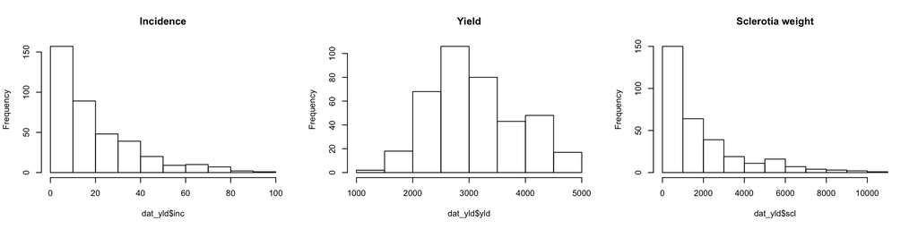

```r
par(mfrow= c(1,3))
hist(dat_yld$inc, main = "Incidence")
hist(dat_yld$yld, main =  "Yield")
hist(dat_yld$scl, main = "Sclerotia weight")
```

Let’s now visualize the two relationships of interest, conditioned to study, and add a regression line (extended to the full range) for each study with variable number of pair of observation. Note that soybean yield decreases with the increase of white mold incidence. On the other hand, sclerotia weight increase with the increase of disease incidence. The variability in the incidence in a single study was due to differences in fungicide efficacy. Note that 35 and 29 studies were avaible for the inc-yld and inc-scl, respectively (6 plots are empty for inc-scl because data was not available).

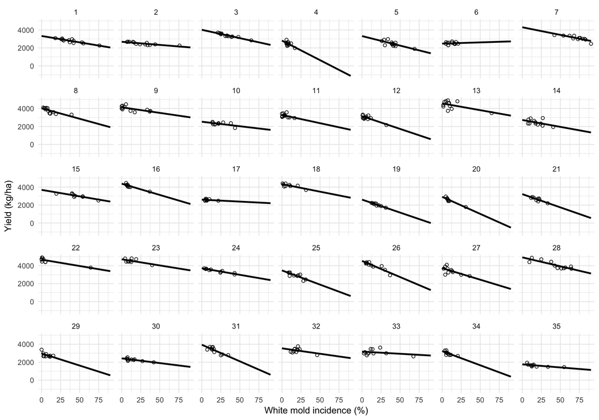

```r
library(ggplot2)
library(ggthemes)
ggplot(dat_yld, aes(inc, yld))+
       geom_point(shape = 1)+
       stat_smooth(method = lm, fullrange=TRUE, se = F, col = "black")+
       ylab("Yield (kg/ha)")+
       xlab("White mold incidence (%)")+
       theme_minimal()+
       facet_wrap(~ study, ncol = 7, scales = "fixed")
```

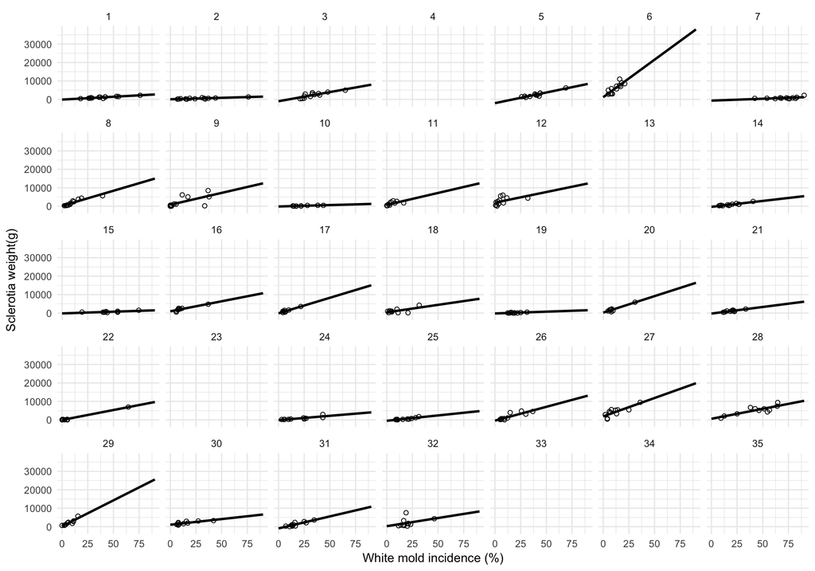

```r
ggplot(dat_yld, aes(inc, scl))+
       geom_point(shape = 1)+
       stat_smooth(method = lm, fullrange=TRUE, se = F, col = "black")+
       ylab("Sclerotia weight(g)")+
       xlab("White mold incidence (%)")+
       theme_minimal()+
       facet_wrap(~ study, ncol = 7, scales = "fixed")
```

# Meta-analytic models

## Incidence-yield

The procedures described below are the same for the two studied relationships. For each one, we summarized the Fisher’s Z as the effect size for the study of the strenght of the association between white mold incidence and soybean yield, and the regression coefficients estimated by a random-coefficients modelling framework to determine the functional relationship between the two variables.

### Correlation coefficient

Here I use the `dplyr::do` and `tidyr::broom` functions to extract the correlation statistics from each of the studies and assign them to the `cor_yld_inc` dataframe.

```r
cor_yld_inc <- dat_yld %>%
  do(tidy(cor.test(.$inc, .$yld)))
```

Let’s extract the first row of each study from the `dat_yld` dataframe and then combine with the new `cor_yld_inc` dataframe that contains the correlation statistics. We will add a new column (n) for the number of data points per study using the `mutate` function.

```r
dat_yld2 <- filter(dat_yld, row_number() == 1)
dat_yld3 <- full_join(cor_yld_inc, dat_yld2, by = "study") %>%
           mutate(n = parameter + 2)
```

The Fisher’s Z was used as effect-size because of its better statistical property than the Pearson’s r. We obtain the Fisher’s Z and sampling variance of each study with the `escalc` function of the `metafor` package that calculates and adds them to the dataframe. Note that the effec-size and sampling variance are indicated by `yi` and `vi`, the standard notations used in `metafor` when using the `escalc` function. Let’s see how the dataframe looks like.

```r
library(metafor)
dat_yld3 <- escalc(measure = "ZCOR", ri = estimate, ni = n, data = dat_yld3)

head(dat_yld3)
```

```
##   study   estimate   statistic      p.value parameter   conf.low   conf.high                               method alternative treat    season harvest_year                   location state country
## 1     1 -0.8999278  -6.8450829 2.782235e-05        11 -0.9699609 -0.69213607 Pearson's product-moment correlation   two.sided     1 2008/2009         2009                 Montividiu    GO  Brazil
## 2     2 -0.8149448  -4.6638241 6.894202e-04        11 -0.9426562 -0.47907499 Pearson's product-moment correlation   two.sided     1 2008/2009         2009 Sao Miguel do Passa Quatro    GO  Brazil
## 3     3 -0.9566920 -10.8999169 3.105025e-07        11 -0.9872663 -0.85795439 Pearson's product-moment correlation   two.sided     1 2008/2009         2009                   Silvania    GO  Brazil
## 4     4 -0.6139396  -2.5795901 2.560901e-02        11 -0.8704696 -0.09513615 Pearson's product-moment correlation   two.sided     1 2008/2009         2009               Ponta Grossa    PR  Brazil
## 5     5 -0.7467931  -3.7242443 3.356899e-03        11 -0.9194503 -0.33270774 Pearson's product-moment correlation   two.sided     1 2008/2009         2009              Maua da Serra    PR  Brazil
## 6     6  0.1125625   0.3757154 7.142732e-01        11 -0.4674118  0.62479767 Pearson's product-moment correlation   two.sided     1 2008/2009         2009                 Nova Ponte    MG  Brazil
##   elevation   region elevation_class inc_check inc_class yld_check yld_class inc  scl  yld  n      yi     vi
## 1       921 Northern             low        76      high      2265       low  76 2194 2265 13 -1.4718 0.1000
## 2      1031 Northern            high        76      high      2257       low  76 1331 2257 13 -1.1416 0.1000
## 3      1050 Northern            high        65      high      2839      high  65 5013 2839 13 -1.9053 0.1000
## 4      1021 Southern            high        17       low      1986       low  17   NA 1986 13 -0.7152 0.1000
## 5      1029 Southern            high        69      high      1893       low  69 6216 1893 13 -0.9657 0.1000
## 6       999 Northern            high        21       low      2476       low  21 8500 2476 13  0.1130 0.1000
```

#### Random-effects model

A [random-effects](http://www.metafor-project.org/doku.php/tips:rma.uni_vs_rma.mv) meta-analytiic model was fitted to these data using a maximum likelihood estimator for the amount of heterogeneity.

```r
ma_cor_yld <- rma.uni(yi, vi, method = "ML", data = dat_yld3)
summary(ma_cor_yld)
```

```
##
## Random-Effects Model (k = 35; tau^2 estimator: ML)
##
##   logLik  deviance       AIC       BIC      AICc
## -23.1897   53.8742   50.3794   53.4901   50.7544
##
## tau^2 (estimated amount of total heterogeneity): 0.0953 (SE = 0.0531)
## tau (square root of estimated tau^2 value):      0.3087
## I^2 (total heterogeneity / total variability):   42.97%
## H^2 (total variability / sampling variability):  1.75
##
## Test for Heterogeneity:
## Q(df = 34) = 61.1764, p-val = 0.0029
##
## Model Results:
##
## estimate       se     zval     pval    ci.lb    ci.ub
##  -1.0111   0.0799 -12.6553   <.0001  -1.1677  -0.8545      ***
##
## ---
## Signif. codes:  0 '***' 0.001 '**' 0.01 '*' 0.05 '.' 0.1 ' ' 1
```

Back-transform z to obtain overall mean r.

```r
pred_r <- predict(ma_cor_yld, transf = transf.ztor)
pred_r
```

```
##     pred   ci.lb   ci.ub   cr.lb   cr.ub
##  -0.7662 -0.8235 -0.6934 -0.9269 -0.3681
```

#### Mixed-effects model

The random-effects model fitted previously assumes that the heterogeneity in the true correlation coefficients (Fisher’s Z) is purely random. However, there may be differences among the individual effects that are (at least in part) related to study-specific variables. These variable can be treated as “moderators” in the model. We considered here: year, region, elevation, or disease and yield levels in the untreated check, as indicative of the disease pressure.

Our mixed-effect model tests one moderator variable, each at a time, as a fixed effects. The goal was is examine to what extent the moderators included in the model influence the size of the average true effect. The heterogeneity among the true effect-sizes is evaluated based on significance of the Cochran Q test and the *I*<sup>2</sup> index that measures the extent of heterogeneity of the true effect-sizes.

```r
# season
ma_cor_yld_year <- rma(yi, vi, sei="",  mods = ~season, method = "ML",   data = dat_yld3)

## region
ma_cor_yld_region <- rma(yi, vi, mods = ~region, method = "ML",data = dat_yld3)

## elevation as continuous
ma_cor_yld_elevation <- rma(yi, vi, mods = ~elevation, method = "ML", data = dat_yld3)

## elevation as category
ma_cor_yld_elevation2 <- rma(yi, vi, mods = ~elevation_class, method = "ML", data = dat_yld3)

## incidence in the check as continuous
ma_cor_yld_inc <- rma(yi, vi, mods = ~inc_check, method = "ML", data = dat_yld3)

## incidence in the check as categorical
ma_cor_yld_inc2 <- rma(yi, vi, mods = ~inc_class, method = "ML", data = dat_yld3)

## yield in the check as continuous
ma_cor_yld_yld <- rma(yi, vi, mods = ~yld_check, method = "ML", data = dat_yld3)

## yield in the check as categorical
ma_cor_yld_yld2 <- rma(yi, vi, mods = ~yld_class, method = "ML", data = dat_yld3)
```

Let’s check the table and see which variables significantly affected the heterogeneity and how much the variance was accounted for when including the moderator variable. It sees we have only one variable with a marginally significant P-value.

```r
table_yld <- frame_data(
~"Moderator", ~"Test of moderator", ~"R2",
"Season", ma_cor_yld_year$QMp,  ma_cor_yld_year$R2,
"Region",  ma_cor_yld_region$QMp, ma_cor_yld_region$R2,
"Elevation categorical", ma_cor_yld_elevation$QMp,  ma_cor_yld_elevation$R2,
"Elevation continuous", ma_cor_yld_elevation2$QMp, ma_cor_yld_elevation2$R2,
"Incidence categorical", ma_cor_yld_inc$QMp, ma_cor_yld_inc$R,
"Yield continous",  ma_cor_yld_yld$QMp, ma_cor_yld_yld$R2,
"Yield categorical", ma_cor_yld_yld2$QMp, ma_cor_yld_yld2$R2
)

kable(table_yld, format = "pandoc", caption = "P-value for the test for the effect of moderator  and the amount of variance (heterogeneity) accounted for by the moderator (R2 statistics)")
```

P-value for the test for the effect of moderator and the amount of variance (heterogeneity) accounted for by the moderator (R2 statistics)

| Moderator | Test of moderator | R2 |
| --- | --- | --- |
| Season | 0.4612331 | 15.2311624 |
| Region | 0.3253424 | 6.4018736 |
| Elevation categorical | 0.2620535 | 7.8577561 |
| Elevation continuous | 0.8234688 | 0.2695911 |
| Incidence categorical | 0.0604829 | 24.1929491 |
| Yield continous | 0.9372820 | 0.0985151 |
| Yield categorical | 0.8651536 | 0.3714379 |

#### Forest plot

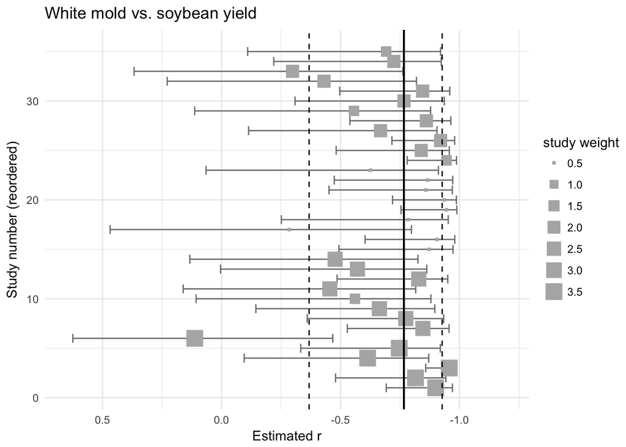

```r
wi    <- 1/sqrt(dat_yld3$vi)
size  <- 0.5 + 3.0 * (wi - min(wi))/(max(wi) - min(wi))
library(ggplot2)
dat_yld3 %>%
  ggplot(aes(x = study, y = estimate)) +
  geom_errorbar(aes(ymin = conf.low, ymax = conf.high), color="grey50") +
  geom_point(aes(size = size), shape = 15, color="grey70") +
 geom_hline(yintercept = pred_r$pred, size=0.75)+
 geom_hline(yintercept = c(pred_r$cr.lb, pred_r$cr.ub), linetype="dashed")+
  coord_flip()+
  scale_y_reverse(limits = c(0.65,-1.2))+
  labs(x = "Slope") +
  theme_minimal() +
  labs(size = "study weight",
       title = "White mold vs. soybean yield",
        y = "Estimated r", x = "Study number (reordered)")
```

## Incidence-sclerotia

### Correlation coefficient

Follow the same procedures as described above.

```r
cor_scl_inc <- dat_yld %>%
 na.omit(dat_yld)%>%
  do(tidy(cor.test(.$inc, .$scl)))
```

Join the two data frames

```r
dat_scl2 <- filter(dat_yld, row_number() == 1) %>%
            na.omit(dat_scl)
dat_scl3 <- full_join(cor_scl_inc, dat_scl2,
                      by = "study") %>%
           mutate(n = parameter + 2)
# create variable with the number of data points in the correlation
```

Obtain Fisher’s Z.

```r
library(metafor)
dat_scl3 <- escalc(measure = "ZCOR", ri = estimate, ni = n, data = dat_scl3)
```

#### Random-effects model

Fit the random-coefficients model.

```r
ma_cor_scl <- rma.uni(yi, vi, method = "ML", data = dat_scl3)
summary(ma_cor_scl)
```

```
##
## Random-Effects Model (k = 29; tau^2 estimator: ML)
##
##   logLik  deviance       AIC       BIC      AICc
## -19.4014   44.9285   42.8028   45.5374   43.2643
##
## tau^2 (estimated amount of total heterogeneity): 0.0822 (SE = 0.0549)
## tau (square root of estimated tau^2 value):      0.2866
## I^2 (total heterogeneity / total variability):   39.32%
## H^2 (total variability / sampling variability):  1.65
##
## Test for Heterogeneity:
## Q(df = 28) = 48.7514, p-val = 0.0089
##
## Model Results:
##
## estimate       se     zval     pval    ci.lb    ci.ub
##   1.2564   0.0852  14.7462   <.0001   1.0894   1.4234      ***
##
## ---
## Signif. codes:  0 '***' 0.001 '**' 0.01 '*' 0.05 '.' 0.1 ' ' 1
```

Back-transform Z to r.

```r
pred_r_scl <- predict(ma_cor_scl, transf = transf.ztor)
pred_r_scl
```

```
##    pred  ci.lb  ci.ub  cr.lb  cr.ub
##  0.8501 0.7967 0.8903 0.5851 0.9510
```

#### Mixed-effects model

Same as previously described.

```r
# season
ma_cor_scl_year <- rma(yi, vi, mods = ~season, method = "ML",   data = dat_scl3)

## region
ma_cor_scl_region <- rma(yi, vi, mods = ~region, method = "ML",data = dat_scl3)

## elevation as continuous
ma_cor_scl_elevation <- rma(yi, vi, mods = ~elevation, method = "ML", data = dat_scl3)

## elevation as category
ma_cor_scl_elevation2 <- rma(yi, vi, mods = ~elevation_class, method = "ML", data = dat_scl3)

## incidence in the check as continuous
ma_cor_scl_inc <- rma(yi, vi, mods = ~inc_check, method = "ML", data = dat_scl3)

## incidence in the check as categorical
ma_cor_scl_inc2 <- rma(yi, vi, mods = ~inc_class, method = "ML", data = dat_scl3)

## yield in the check as continuous
ma_cor_scl_yld <- rma(yi, vi, mods = ~yld_check, method = "ML", data = dat_scl3)

## yield in the check as categorical
ma_cor_scl_yld2 <- rma(yi, vi, mods = ~yld_class, method = "ML", data = dat_scl3)
```

```r
table_scl <- frame_data(
~"Moderator", ~"Test of moderator", ~"R2",
"Season", ma_cor_scl_year$QMp,  ma_cor_scl_year$R2,
"Region",  ma_cor_scl_region$QMp, ma_cor_scl_region$R2,
"Elevation categorical", ma_cor_scl_elevation$QMp,  ma_cor_scl_elevation$R2,
"Elevation continuous", ma_cor_scl_elevation2$QMp, ma_cor_scl_elevation2$R2,
"Incidence categorical", ma_cor_scl_inc$QMp, ma_cor_scl_inc$R,
"Yield continous",  ma_cor_scl_yld$QMp, ma_cor_scl_yld$R2,
"Yield categorical", ma_cor_scl_yld2$QMp, ma_cor_scl_yld2$R2
)

kable(table_yld, format = "markdown", caption = "P-value of the test for the effect of the moderator and the amount of variance (heterogeneity) accounted for by the moderator (R2 statistics)")
```

| Moderator | Test of moderator | R2 |
| --- | --- | --- |
| Season | 0.4612331 | 15.2311624 |
| Region | 0.3253424 | 6.4018736 |
| Elevation categorical | 0.2620535 | 7.8577561 |
| Elevation continuous | 0.8234688 | 0.2695911 |
| Incidence categorical | 0.0604829 | 24.1929491 |
| Yield continous | 0.9372820 | 0.0985151 |
| Yield categorical | 0.8651536 | 0.3714379 |

#### Forest plot

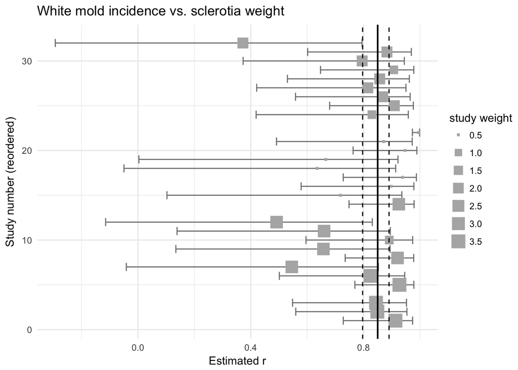

```r
wi    <- 1/sqrt(dat_scl3$vi)
size  <- 0.5 + 3.0 * (wi - min(wi))/(max(wi) - min(wi))
dat_scl3 %>%
  ggplot(aes(x = study, y = estimate)) +
  geom_errorbar(aes(ymin = conf.low, ymax = conf.high), color="grey50") +
  geom_point(aes(size = size), shape = 15, color="grey70") +
  geom_hline(yintercept = pred_r_scl$pred, size=0.75)+
  geom_hline(yintercept = c(pred_r_scl$ci.lb, pred_r_scl$ci.ub), linetype="dashed")+
  coord_flip()+
  labs(x = "Slope")+
  theme_minimal()+
  labs(size = "study weight",
       title = "White mold incidence vs. sclerotia weight",
        y = "Estimated r", x = "Study number (reordered)")
```

# References

Dalla Lana, F., Ziegelmann, P. K., Maia, A. de H. N., Godoy, C. V., & Del Ponte, E. M. (2015). Meta-Analysis of the Relationship Between Crop Yield and Soybean Rust Severity. Phytopathology, 105(3), 307–315. doi:10.1094/phyto-06-14-0157-r

Madden, L. V., & Paul, P. A. (2009). Assessing Heterogeneity in the Relationship Between Wheat Yield and Fusarium Head Blight Intensity Using Random-Coefficient Mixed Models. Phytopathology, 99(7), 850–860. doi:10.1094/phyto-99-7-0850

```
##  setting  value
##  version  R version 3.3.1 (2016-06-21)
##  system   x86_64, darwin13.4.0
##  ui       X11
##  language (EN)
##  collate  en_US.UTF-8
##  tz       America/Sao_Paulo
##  date     2016-10-06
```

```
## Packages -----------------------------------------------------------------------------------------------------------------------------------------------------------------------------------------------
```

[output not shown]